# Increase in the injuries of football players overtime

*Is the increase in playing time a cause for the increase in football injuries?*

## Goal

*To analyze athlete injury data over multiple seasons in order to determine whether the frequency and severity of injuries have increased over time. This project will involve data cleaning, aggregation, and visualization to uncover trends in injury counts, durations, and missed games, with the objective of informing decisions around player health, training practices, and risk management strategies. This analysis explores a dataset on injuries and demonstrates data loading, exploration, and visualization.*

##Pre-analysis

### Install and Load Required Packages

#### Read Excel file

```r
data <- read_excel("/Users/liev/Documents/Data Analysis Portfolio Datasets/InjuriesGoodDAta.xlsx")
```

#### Preview the data

```r
head(data)
```

```
## # A tibble: 6 × 9
##   Season Injury           from  until Days  `Games missed` player_name player_id
##   <chr>  <chr>            <chr> <chr> <chr> <chr>          <chr>           <dbl>
## 1 00/01  Metatarsal frac… May … Aug … 86 d… 7              David Piza…      5896
## 2 00/01  Foot injury      Mar … May … 53 d… 7              David Piza…      5896
## 3 00/01  Achilles tendon… Mar … Apr … 17 d… 4              Emre Belöz…      5782
## 4 00/01  Calf stiffness   Dec … Dec … 8 da… 3              Emre Belöz…      5782
## 5 00/01  Calf strain      Sep … Nov … 37 d… 9              Emre Belöz…      5782
## 6 00/01  Edema in the kn… Sep … Sep … 6 da… 2              Emre Belöz…      5782
## # ℹ 1 more variable: url_injuries <chr>
```

## Data Cleaning & Validation Processes

### Checking for missing or null data

```r
missing_found <- FALSE

for (col in names(data)) {
  missing_count <- sum(is.na(data[[col]]))
  if (missing_count > 0) {
    cat("Column", col, "has", missing_count, "missing values\n")
    missing_found <- TRUE
  }
}

if (!missing_found) {
  cat("✅ Data is complete – no missing values found.\n")
}
```

```
## ✅ Data is complete – no missing values found.
```

### Removing unnescessary date from rows

```r
data_clean <- data %>%
  mutate(
    Days = str_remove(Days, " days"),
    Days = as.numeric(Days)
  )

head(data_clean, 10)
```

```
## # A tibble: 10 × 9
##    Season Injury          from  until  Days `Games missed` player_name player_id
##    <chr>  <chr>           <chr> <chr> <dbl> <chr>          <chr>           <dbl>
##  1 00/01  Metatarsal fra… May … Aug …    86 7              David Piza…      5896
##  2 00/01  Foot injury     Mar … May …    53 7              David Piza…      5896
##  3 00/01  Achilles tendo… Mar … Apr …    17 4              Emre Belöz…      5782
##  4 00/01  Calf stiffness  Dec … Dec …     8 3              Emre Belöz…      5782
##  5 00/01  Calf strain     Sep … Nov …    37 9              Emre Belöz…      5782
##  6 00/01  Edema in the k… Sep … Sep …     6 2              Emre Belöz…      5782
##  7 00/01  Muscle strain   Jul … Oct …    78 12             Javier Zan…      1161
##  8 00/01  unknown injury  Dec … Dec …     4 1              Jonas De R…     13051
##  9 00/01  Cruciate ligam… Feb … Dec …   319 65             Massimo Am…      5818
## 10 00/01  Cruciate ligam… Feb … Dec …   319 65             Massimo Am…      5818
## # ℹ 1 more variable: url_injuries <chr>
```

#### Data Analysis!

In my analysis the goal was to show an increase in injuries over time, in both severity and frequency.

### What is the trend in the injuries overtime?

Let’s visualize this

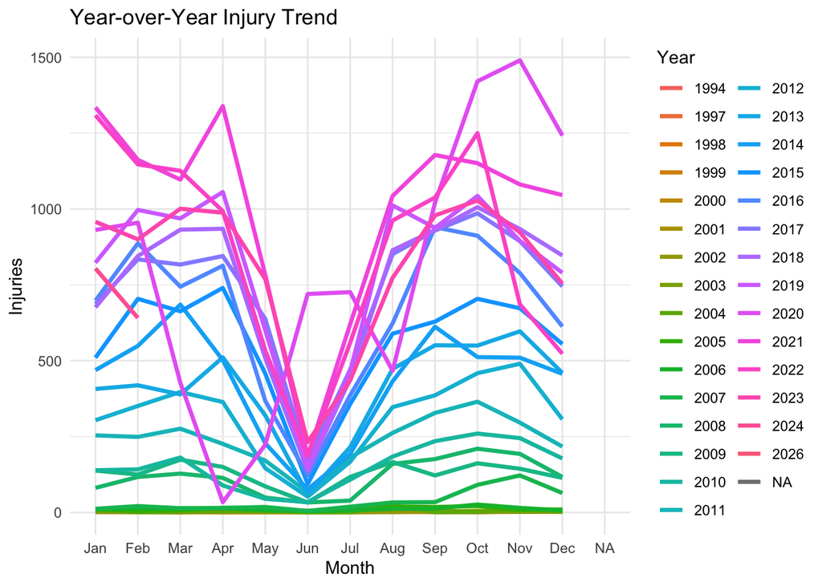

```r
# Convert the 'from' column to Date type
data <- data %>%
  mutate(from = as.Date(from, format = "%b %d, %Y"),
         Year = year(from),
         Month = month(from, label = TRUE))

# Group by Year and Month
yoY <- data %>%
  group_by(Year, Month) %>%
  summarise(Incidents = n())

# Plot
ggplot(yoY, aes(x = Month, y = Incidents, group = Year, color = as.factor(Year))) +
  geom_line(size = 1.2) +
  labs(title = "Year-over-Year Injury Trend",
       x = "Month",
       y = "Injuries",
       color = "Year") +
  theme_minimal()
```

Trend showing the monthly distribution of injuries overtime.

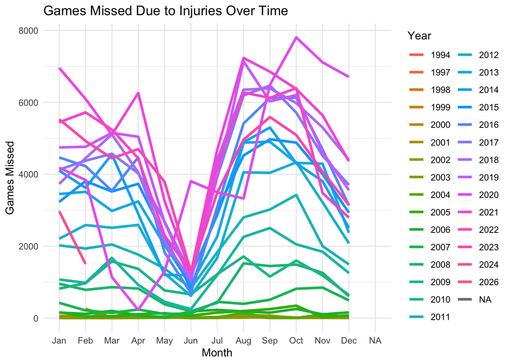

```r
data <- data %>%
  mutate(
    from = as.Date(from, format = "%b %d, %Y"),
    Year = year(from),
    Month = month(from, label = TRUE),
    `Games missed` = as.numeric(`Games missed`)
  )

# Summarize games missed by year and month
games_missed_summary <- data %>%
  group_by(Year, Month) %>%
  summarise(GamesMissed = sum(`Games missed`, na.rm = TRUE))

# Plot it
ggplot(games_missed_summary, aes(x = Month, y = GamesMissed, group = Year, color = as.factor(Year))) +
  geom_line(size = 1.2) +
  labs(title = "Games Missed Due to Injuries Over Time",
       x = "Month",
       y = "Games Missed",
       color = "Year") +
  theme_minimal()
```

### Is there an increase in the severity of injuries overtime?

Lets visualize it

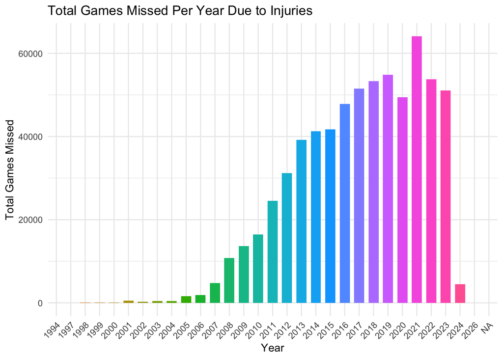

```r
# Parse the date and ensure Games missed is numeric
data <- data %>%
  mutate(
    from = as.Date(from, format = "%b %d, %Y"),
    Year = year(from),
    `Games missed` = as.numeric(`Games missed`)
  )

# Summarize total games missed per year
yearly_missed <- data %>%
  group_by(Year) %>%
  summarise(TotalGamesMissed = sum(`Games missed`, na.rm = TRUE))

# Plot the bar chart
ggplot(yearly_missed, aes(x = as.factor(Year), y = TotalGamesMissed, fill = as.factor(Year))) +
  geom_bar(stat = "identity", width = 0.7, show.legend = FALSE) +
  labs(title = "Total Games Missed Per Year Due to Injuries",
       x = "Year",
       y = "Total Games Missed") +
  theme_minimal() +
  theme(axis.text.x = element_text(angle = 45, hjust = 1))
```

### What is the trend line for the total number of games missed per year?

Let’s visualize it

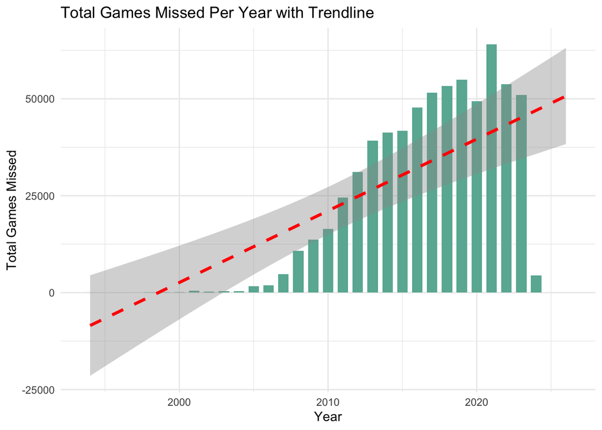

```r
data <- data %>%
  mutate(
    from = as.Date(from, format = "%b %d, %Y"),
    Year = year(from),
    `Games missed` = as.numeric(`Games missed`)
  )

# Aggregate total games missed per year
yearly_missed <- data %>%
  group_by(Year) %>%
  summarise(TotalGamesMissed = sum(`Games missed`, na.rm = TRUE))

# Plot with linear regression trendline
ggplot(yearly_missed, aes(x = Year, y = TotalGamesMissed)) +
  geom_bar(stat = "identity", fill = "#69b3a2", width = 0.7) +
  geom_smooth(method = "lm", se = TRUE, color = "red", linetype = "dashed", size = 1.2) +
  labs(title = "Total Games Missed Per Year with Trendline",
       x = "Year",
       y = "Total Games Missed") +
  theme_minimal()
```

## Conclusion

Over time there has been an increase in both the frequency and severity of injuries, with a peak during the COVID-19 months. Injuries tend to spike in August, when the season begins, and October, mid-season.

This R data analysis project provides insights into athlete injuries and their impacts, helping inform player safety and training protocols.